# ЕГЭ 2017 Вариант 4 EGE 2017 Variant 4

that finds and displays the sum of the elements of the largest increasing sequence of consecutive array elements.

The original data is declared as shown below.

It is forbidden to use variables not described below, but it is allowed not to use a part of them.

- `Declare an array A of 40 elements`.
- `Declare the integer variables I, L, Lmax, S, Smax`.
- `In the cycle from 1 to 40, we introduce the elements of array A from the 1st to the 40th`.
- `...`

As an answer, you need to bring the program fragment (or description of the algorithm in natural language), which should be in place of the ellipsis.

You can also write the solution in another programming language (specify the name and the version of the programming language used, for example `Borland Pascal 7.0`) or as a flowchart.

In this case, you must use the same source data and variables that were proposed in the condition (for example, in a sample written in the natural language).

Python

R

```python
N = 40
A = []

#use integer variables I, L, Lmax, S, Smax

for I in range(N):
    A.append(int(input()))
```

```r
N <- 40
A <- vector(length=N)
#use integer variables I, L, Lmax, S, Smax

for (I in 1:N){
    A[I] <- as.integer(readline())
...
}
```

```python
N = 40
A = []
Lmax, Smax = 0, 0
L, S = 0, 0
# The fragment instead of the ellipsis
for I in range(N):
    A.append(int(input()))

    if A[I] > A[I-1]:
        L += 1
        S += A[I]
        if (L == Lmax and S > Smax):
            Smax = S
        elif L > Lmax:
            Lmax, Smax = L, S
    else:
        L, S = 1, A[I]

print(Smax)
```

```
-10
-20
-30
-40
-50
-40
-30
-20
-10
10
20
30
40
50
60
70
80
90
80
70
60
50
40
30
20
10
-10
-20
-30
-20
-10
10
20
30
40
50
60
70
80
90
300
```

```python
import sys
version = 'python '+str(sys.version_info[0])+'.'+str(sys.version_info[1])
program_fragment = \
"""
N = 40
A = []
Lmax, Smax = 0, 0
L, S = 0, 0
# The fragment instead of the ellipsis
for I in range(N):
    A.append(int(input()))

    if A[I] > A[I-1]:
        L += 1
        S += A[I]
        if (L == Lmax and S > Smax):
            Smax = S
        elif L > Lmax:
            Lmax, Smax = L, S
    else:
        L, S = 1, A[I]

print(Smax)
"""
```

```python
answer_dictionary[25] = [version, program_fragment]
print("Answer:", answer_dictionary[25])
```

```
Answer: ['python 3.6', '\nN = 40\nA = []\nLmax, Smax = 0, 0\nL, S = 0, 0\n# The fragment instead of the ellipsis\nfor I in range(N):\n    A.append(int(input()))\n    \n    if A[I] > A[I-1]:\n        L += 1\n        S += A[I]\n        if (L == Lmax and S > Smax):            \n            Smax = S\n  …
```

[figure not shown]

Два игрока, Петя и Ваня, играют в следующую игру. Перед игроками лежит куча камней. Игроки ходят по очереди, первый ход делает Петя.

За один ход игрок может добавить в кучу один или два камня или увеличить количество камней в куче в три раза.

Например, имея кучу из 15 камней, за один ход можно получить кучу из 16, 17 или 45 камней.

У каждого игрока, чтобы делать ходы, есть неограниченное количество камней.

Игра завершается в тот момент, когда количество камней в куче становится **не менее 31**.

Победителем считается игрок, сделавший последний ход, то есть первым получивший кучу, в которой будет 31 или больше камней.

В начальный момент в куче было S камней, **1 ≤ S ≤ 30**.

Говорят, что игрок имеет выигрышную стратегию, если он может выиграть при любых ходах противника.

Описать стратегию игрока — значит описать, какой ход он должен сделать в любой ситуации,

которая ему может встретиться при различной игре противника.

Выполните следующие задания. Во всех случаях обосновывайте свой ответ.

$1$.

- а) Укажите все такие значения числа S, при которых Петя может выиграть в один ход.

Обоснуйте, что найдены все нужные значения S, и укажите выигрывающий ход для каждого указанного значения S.

- б) Укажите такое значение S, при котором Петя не может выиграть за один ход,

но при любом ходе Пети Ваня может выиграть своим первым ходом. Опишите выигрышную стратегию Вани.

$2$. Укажите два значения S, при которых у Пети есть выигрышная стратегия, причём выполняются два условия:

- а) Петя не может выиграть за один ход;
- б) Петя может выиграть своим вторым ходом независимо от того, как будет ходить Ваня.

Для каждого указанного значения S опишите выигрышную стратегию Пети.

$3$. Укажите такое значение S, при котором выполняются оба пункта:

- а) у Вани есть выигрышная стратегия, позволяющая ему выиграть первым или вторым ходом при любой игре Пети;
- б) у Вани нет стратегии, которая позволит ему гарантированно выиграть первым ходом.

Для указанного значения S опишите выигрышную стратегию Вани.

Постройте дерево всех партий, возможных при этой выигрышной стратегии Вани (в виде рисунка или таблицы).

На рёбрах дерева указывайте, кто делает ход, в узлах — количество камней в куче.

Two players, Petya and Vanya, play the next game. There is a bunch of stones in front of them. Players move by turns, the first step is made by Petya.

In one move, a player can add one or two stones to the pile or increase the number of stones in the heap by three times.

For example, having a bunch of 15 stones, you can get a heap of 16, 17 or 45 stones in one move. Each player has an unlimited number of stones to play.

The game ends at the moment when the number of stones in the heap becomes **at least 31**.

The winner is the player who made the last step, that is, the first to receive a pile, in which there will be 31 or more stones.

At the initial moment, the heap had S stones, **1 ≤ S ≤ 30**.

It is said that a player has a winning strategy if he can win at any moves of the opponent.

To describe a player's strategy is to describe what course he should take in any situation

that he can meet in a different game of the opponent.

Complete the following tasks. In all cases, justify your answer.

$1$.

- a) Indicate all such values of the number S at which Petya can win in one turn.

Justify that you have found all the required values of S, and indicate the winning move for each specified value of S.

- b) Specify a value S for which Petya cannot win in one move, but at any his step Vanya can win with his first move.

Describe the Vanya's winning strategy.

$2$. Specify two values of S for which Petya has a winning strategy, and two conditions are satisfied:

- a) Petya cannot win in one move;
- b) Petya can win with his second move regardless of how Vanya will walk.

For each specified value of S, describe the Petya's winning strategy.

$3$. Specify an S value such that both points are true:

- a) Vanya has a winning strategy that allows him to win by the first or second move with any Petya's game;
- b) Vanya does not have a strategy that will allow him to win by the first step with a guarantee.

For the specified value of S, describe the Vanya's winning strategy.

Build a tree of all the possible batches with this winning strategy of Vanya (in the form of a picture or a table).

On the edges of the tree indicate who is making the move, in the nodes - the number of stones in the heap.

$1.$

- a. `11≤S≤30`, $S \in \{11,...,30\}$. Петя выигрывает одним ходом - утраивая количество камней: `33≤3*S≤90`, $3∗S \in \{33,...,90\}$. При `1≤S≤10`, $S \in \{1,...,10\}$ невозможно выиграть одним ходом: $S+1 \in \{2,...,11\}$, `3≤S+2≤12`, $S+2 \in \{3,...,12\}$; `3≤3*S≤30`, $3*S \in \{3,...,30\}$.
- б. `S=10`. При любом следующем шаге `10 -> 11 (P +1)`, `10 -> 12 (P +2)` или `10 -> 30 (P *3)` Петя выиграть не сможет, а Ваня гарантированно победит, утроив результат на следующем этапе: `11 -> 33 (V *3)`, `12 -> 36 (V *3)` или `30 -> 90 (V *3)`.
- a. `11≤S≤30`, $S \in \{11,...,30\}$. Petya wins by one step - tripling the number of stones: `33≤3*S≤90`, $3∗S \in \{33,...,90\}$. At `1≤S≤10`, $S \in\{1,...,10\}$ it is not possible to win by one move: `2≤S+1≤11`, $S+1 \in \{2,...,11\}$; `3≤S+2≤12`, $S+2 \in \{3,...,12\}$; `3≤3*S≤30`, $3*S \in \{3,...,30\}$.
- b. `S=10`. In this case, at any next step, `10 -> 11 (P +1)`, `10 -> 12 (P +2)` or `10 -> 30 (P *3)` Petya will not be able to win, and Vanya will win by tripling the result in the next stage: `11 -> 33 (V *3)`, `12 -> 36 (V *3)` or `30 -> 90 (V *3)`.

$2.$

`S=8` или `S=9`. Петя должен выбрать тогда ход `8 -> 10 (P +2)` или `9 -> 10 (P +1)`. При любом следующем шаге `10 -> 11 (V +1)`, `10 -> 12 (V +2)` или `10 -> 30 (V *3)` Ваня выиграть не сможет, а Петя победит, утроив результат на следующем этапе: `11 -> 33 (P *3)`, `12 -> 36 (P *3)` или `30 -> 90 (P *3)`.

`S=8` or `S=9`. Petya should choose the step `8 -> 10 (P +2)` or `9 -> 10 (P +1)`. At any next step, `10 -> 11 (V +1)`, `10 -> 12 (V +2)` or `10 -> 30 (V *3)` Vanya cannot win, but Petya wins by tripling the result in the next stage `11 -> 33 (P *3)`, `12 -> 36 (P *3)` or `30 -> 90 (P *3)`.

$3.$

`S=7`. Выигрышная стратегия Вани:

- Если первый ход Пети `7 -> 8 (P +1)` или `7 -> 9 (P +2)`, то Ваня должен выбрать ход `8 -> 10 (V +2)` или `9 -> 10 (V +1)`. В этом случае при любом следующем шаге `10 -> 11 (P +1)`, `10 -> 12 (P +2)` или `10 -> 30 (P *3)` Петя выиграть не сможет, а Ваня гарантированно победит, утроив результат на следующем этапе: `11 -> 33 (V *3)`, `12 -> 36 (V *3)` или `30 -> 90 (V *3)`.
- Если первый ход Пети `7 -> 21 (P *3)`, то Ваня выигрывает первым своим ходом, утроив количество камней: `21 -> 63 (V *3)`.

Ваня не сможет гарантированно победить первым же ходом при такой стартовой позиции.

`S=7`. Vanya's winning strategy:

- If the first move of Petya `7 -> 8 (P +1)` or `7 -> 9 (P +2)`, then Vanya should choose the course `8 -> 10 (V +2)` or `9 -> 10 (V +1)`. In this case, at any next step, `10 -> 11 (P +1)`, `10 -> 12 (P +2)` or `10 -> 30 (P *3)` Petya will not be able to win, and Vanya will win by tripling the result in the next stage: `11 -> 33 (V *3)`, `12 -> 36 (V *3)` or `30 -> 90 (V *3)`.
- If the first move of Petya `7 -> 21 (P *3)`, then Vanya wins by his first move, tripling the number of stones: `21 -> 63 (V *3)`.

It is not possible for Vanya to win by the first move with a guarantee with this start position.

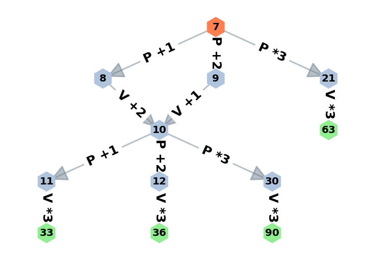

```python
import pydot
from networkx.drawing.nx_pydot import graphviz_layout

plt.figure(figsize=(12,9))

G4 = nx.DiGraph()

G4.add_edges_from([('7', '8'),('7','9'),('7','21')])
G4.add_edges_from([('8', '10'),('9','10'),('21','63')])
G4.add_edges_from([('10', '11'),('10','12'),('10','30')])
G4.add_edges_from([('11', '33'),('12','36'),('30','90')])

pos = graphviz_layout(G4, prog='dot')

edge_labels={('7', '8'):'P +1', ('7','9'):'P +2', ('7','21'):'P *3',
             ('8','10'):'V +2', ('9','10'):'V +1', ('21','63'):'V *3',
             ('10', '11'):'P +1', ('10','12'):'P +2', ('10','30'):'P *3',
             ('11','33'):'V *3', ('12','36'):'V *3', ('30','90'):'V *3'}

node_colors=['coral', 'lightsteelblue', 'lightsteelblue','lightsteelblue',
             'lightsteelblue', 'lightgreen', 'lightsteelblue', 'lightsteelblue',
             'lightsteelblue', 'lightgreen', 'lightgreen', 'lightgreen']

nx.draw_networkx_edges(G4, pos, width=3, alpha=0.5, edge_color='slategray',
                       arrowsize=70, arrowstyle='-|>')
nx.draw_networkx_nodes(G4, pos, node_size=1500, node_shape='h', node_color=node_colors)

nx.draw_networkx_edge_labels(G4, pos, edge_labels, font_size=25, font_weight='bold')
nx.draw_networkx_labels(G4, pos, font_size=20, font_weight='bold')

plt.axis('off')
plt.show()
```

```python
answer_dictionary[26] = """
1.
a.
P*3:11≤S≤30→33≤3*S≤90
b.
S=10
P+1:10→11 ∨ P+2:10→12 ∨ P*3:10→30
V*3:11→33 ∨ V*3:12→36 ∨ V*3:30→90
2.
S=8 ∨ S=9
P+2:8→10 ∨ P+1:9→10
V+1:10→11 ∨ V+2:10→12 ∨ V*3:10→30
P*3:11→33 ∨ P*3:12→36 ∨ P*3:30→90
3.
S=7
P+1:7→8 ∨ P+2:7→9 ∨ P*3:7→21
V+2:8→10 ∨ V+1:9→10 ∨ V*3:21→63
P+1:10→11 ∨ P+2:10→12 ∨ P*3:10→30
V*3:11→33 ∨ V*3:12→36 ∨ V*3:30→90
"""
print("\n","Answer:", answer_dictionary[26])
```

```
 Answer:
1.
a.
P*3:11≤S≤30→33≤3*S≤90
b.
S=10
P+1:10→11 ∨ P+2:10→12 ∨ P*3:10→30
V*3:11→33 ∨ V*3:12→36 ∨ V*3:30→90
2.
S=8 ∨ S=9
P+2:8→10 ∨ P+1:9→10
V+1:10→11 ∨ V+2:10→12 ∨ V*3:10→30
P*3:11→33 ∨ P*3:12→36 ∨ P*3:30→90
3.
S=7
P+1:7→8 ∨ P+2:7→9 ∨ P*3:7→21
V+2:8→10 ∨ V+1:9→10 ∨ V*3:21→63
P+1:10→11 ∨ P+2:10→12 ∨ P*3:10→30
V*3:11→33 ∨ V*3:12→36 ∨ V*3:30→90
```

[figure not shown]

После единых выпускных экзаменов по информатике в район пришла информация о том, какой ученик какой школы сколько баллов набрал. По положению об экзамене каждый район сам определяет, за какой балл нужно поставить какую оценку.

Районный методист решила, что оценку «отлично» должны получить 20% участников (целое число, с отбрасыванием дробной части).

Для этого она должна определить, какой балл должен был набрать ученик, чтобы получить «отлично».

Если невозможно определить такой балл, чтобы «отлично» получили ровно 20% участников, «отлично» должно получить меньше участников, чем 20%.

Если таких участников не окажется (наибольший балл набрали больше 20% участников) — эти и только эти ученики должны получить «отлично».

Напишите эффективную, в том числе и по используемой памяти, программу (укажите используемую версию языка программирования, например, `Borland Pascal 7.0`), которая должна вывести на экран наименьший балл, который набрали участники, получившие «отлично». Известно, что информатику сдавало больше 5-ти учеников. Также известно, что есть такое количество баллов, которое не получил ни один участник.

На вход программе сначала подаётся число учеников, сдававших экзамен. В каждой из следующих N строк находится информация об учениках в формате:

`<Фамилия> <Имя> <Номер школы> <Количество баллов>`,

где `<Фамилия>` — строка, состоящая не более, чем из 30 символов без пробелов, `<Имя>` — строка, состоящая не более, чем из 20 символов без пробелов, `<Номер школы>` — целое число в диапазоне от 1 до 99, `<Количество баллов>` — целое число диапазоне от 0 до 100. Эти данные записаны через пробел, причем ровно один между каждой парой (то есть, всего по три пробела в каждой строке).

Пример входной строки:

`Иванов Иван 50 87`

Пример выходных данных:

`78`

After a final examination in informatics, information was received in the district administration about which pupil of which school scored how many points. According to the regulations on the exam, each district itself determines which scores correspond to which marks.

The District Methodist decided that an "excellent" score should be received by 20% of the participants (an integer, with the discarding of the fractional part).

To do this, she must determine what score the student should have in order to get an "excellent" mark.

If it is impossible to determine such a score that "exactly" 20% of the participants get "excellent", less than 20% of students should get "excellent".

If there are no such participants (the largest score more than 20% of participants have) - these and only these students should get "excellent".

Write an effective program (including the used version of the programming language, for example, `Borland Pascal 7.0`), which displays the smallest score on the screen, which was scored by the participants who received "excellent". It is known that more than 5 students passed computer science. It is also known that there are so many points that no participant has received.

The input for the program is, at first, the number of students (N) who passed the exam. Then each of the following N lines contains information about students in the format:

`<Surname> <Name> <School number> <Score>`,

Example of an input line:

`Ivanov Ivan 50 87`

Example of an output line:

`78`

Пример персональных данных.

1. Аверин Алексей 7 78
2. Бодрова Екатерина 38 81
3. Бондарев Максим 53 65
4. Вершинин Денис 7 87
5. Воронова Галина 7 76
6. Газиев Марат 38 83
7. Грачев Иван 38 67
8. Есин Руслан 53 88
9. Колесникова Мария 38 74
10. Лескова Анна 53 83
11. Мельников Роман 38 77
12. Морозова Жанна 53 88
13. Нестерова Роза 38 81
14. Нигматулин Ринат 7 72
15. Носиков Илья 53 88
16. Ольховский Дмитрий 7 79
17. Петренко Дарья 7 82
18. Робертсон Артур 38 73
19. Стариков Кирилл 53 70
20. Терехов Леонид 7 84

```python
# без использования импортируемых модулей
N = int(input('Число учеников, сдававших экзамен: '))
excellent = int(N/5)
scores = 101*[0]

print('Персональные данные в формате: ')
print('<Фамилия><пробел><Имя><пробел><Номер школы><пробел><Количество баллов>')
print(18*'=-=')

for i in range(N):
    print(("{} ученик").format(i+1))
    string = input().split()

    score = int(string[3])
    scores[score] += 1

excellent = int(N/5)

if scores[100] > excellent:
    exc_number = scores[100]
    exc_score = 100
else:
    exc_number = 0

i = 100
while exc_number + scores[i] <= excellent:
    exc_number += scores[i]
    if scores[i] != 0:
        exc_score = i
    i -= 1

print(18*'=-=' + '\n' + str(exc_score))
```

```
Число учеников, сдававших экзамен: 20
Персональные данные в формате:
<Фамилия><пробел><Имя><пробел><Номер школы><пробел><Количество баллов>
=-==-==-==-==-==-==-==-==-==-==-==-==-==-==-==-==-==-=
1 ученик
Аверин Алексей 7 78
2 ученик
Бодрова Екатерина 38 81
3 ученик
ондарев Максим 53 65
4 ученик
Вершинин Денис 7 87
5 ученик
Воронова Галина 7 76
6 ученик
Газиев Марат 38 83
7 ученик
Грачев Иван 38 67
8 ученик
Есин Руслан 53 88
9 ученик
Колесникова Мария 38 74
10 ученик
Лескова Анна 53 83
11 ученик
Мельников Роман 38 77
12 ученик
Морозова Жанна 53 88
13 ученик
Нестерова Роза 38 81
14 ученик
Нигматулин Ринат 7 72
15 ученик
Носиков Илья 53 88
16 ученик
Ольховский Дмитрий 7 79
17 ученик
Петренко Дарья 7 82
18 ученик
Робертсон Артур 38 73
19 ученик
Стариков Кирилл 53 70
20 ученик
Терехов Леонид 7 84
=-==-==-==-==-==-==-==-==-==-==-==-==-==-==-==-==-==-=
87
```

```python
program=\
"""
N = int(input('Число учеников, сдававших экзамен: '))
excellent = int(N/5)
scores = 101*[0]

print('Персональные данные в формате: ')
print('<Фамилия><пробел><Имя><пробел><Номер школы><пробел><Количество баллов>')
print(18*'=-=')

for i in range(N):
    print(("{} ученик").format(i+1))
    string = input().split()

    score = int(string[3])
    scores[score] += 1

excellent = int(N/5)

if scores[100] > excellent:
    exc_number = scores[100]
    exc_score = 100
else:
    exc_number = 0

i = 100
while exc_number + scores[i] <= excellent:
    exc_number += scores[i]
    if scores[i] != 0:
        exc_score = i
    i -= 1

print(18*'=-=' + '\n' + str(exc_score))
"""
```

```python
answer_dictionary[27] = [version, program]
print("\n","Answer:", answer_dictionary[27])
```

```
 Answer: ['python 3.6', '\nN = int(input(\'Число учеников, сдававших экзамен: \'))\nexcellent = int(N/5)\nscores = 101*[0]\n\nprint(\'Персональные данные в формате: \')\nprint(\'<Фамилия><пробел><Имя><пробел><Номер школы><пробел><Количество баллов>\')\nprint(18*\'=-=\')\n\nfor i in range(N):\n    pr…
```

```python
# с использованием импортируемых модулей
N = int(input("Число учеников, сдававших экзамен: "))
print("Персональные данные в формате: ")
print("<Фамилия><пробел><Имя><пробел><Номер школы><пробел><Количество баллов>")
print(18*"=-= ")

df = pandas.DataFrame(index=range(1,N+1,1),
                      columns=['Фамилия', 'Имя', 'Номер школы', 'Количество баллов'])
df = df.fillna(0)

for i in range(1,N+1,1):
    print(("{} ученик").format(i))
    df.loc[i] = input("").split()
```

```
Число учеников, сдававших экзамен: 20
Персональные данные в формате:
<Фамилия><пробел><Имя><пробел><Номер школы><пробел><Количество баллов>
=-= =-= =-= =-= =-= =-= =-= =-= =-= =-= =-= =-= =-= =-= =-= =-= =-= =-=
1 ученик
Аверин Алексей 7 78
2 ученик
Бодрова Екатерина 38 81
3 ученик
Бондарев Максим 53 65
4 ученик
Вершинин Денис 7 87
5 ученик
Воронова Галина 7 76
6 ученик
Газиев Марат 38 83
7 ученик
Грачев Иван 38 67
8 ученик
Есин Руслан 53 88
9 ученик
Колесникова Мария 38 74
10 ученик
Лескова Анна 53 83
11 ученик
Мельников Роман 38 77
12 ученик
Морозова Жанна 53 88
13 ученик
Нестерова Роза 38 81
14 ученик
Нигматулин Ринат 7 72
15 ученик
Носиков Илья 53 88
16 ученик
Ольховский Дмитрий 7 79
17 ученик
Петренко Дарья 7 82
18 ученик
Робертсон Артур 38 73
19 ученик
Стариков Кирилл 53 70
20 ученик
Терехов Леонид 7 84
```

```python
df['Количество баллов'] = df['Количество баллов'].astype('int32')
df['Номер школы'] = df['Номер школы'].astype('int32')

excellent = int(N / 5)
scores = df['Количество баллов'].value_counts().sort_index(ascending=False)

if scores.index.values[0] == 100 and scores.iloc[0] > excellent:
    exc_number = scores.iloc[0]
    exc_score = 100
else:
    exc_number = 0

for i in range(len(scores)):
    if exc_number + scores.iloc[i] <= excellent:
        exc_number += scores.iloc[i]
        exc_score = scores.index.values[i]

print (exc_score)
```

```
87
```

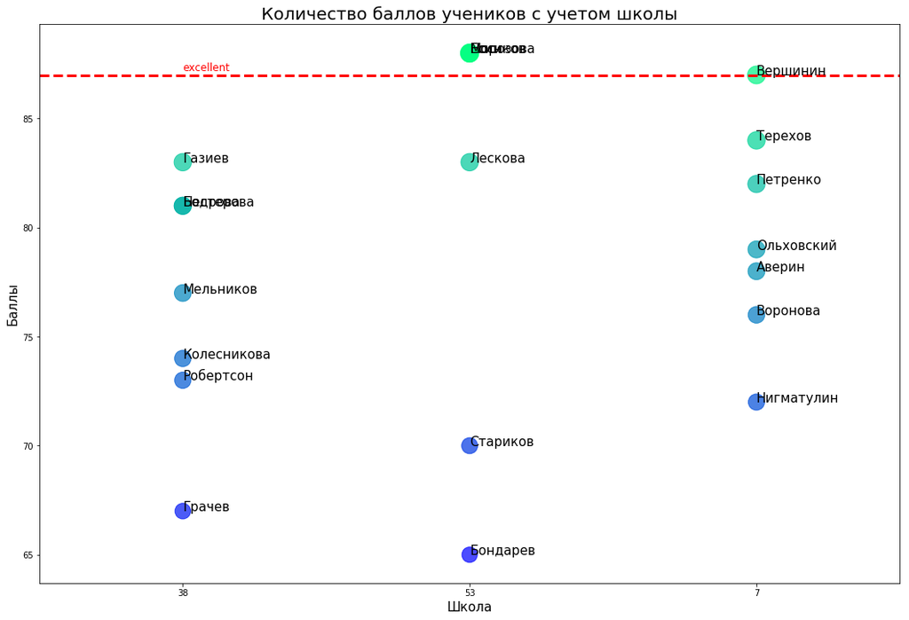

```python
plt.figure(figsize=(18,12))
plt.axhline(exc_score, c='r',ls='--',lw=3)
plt.text(0,exc_score+0.2,'excellent',color='r',fontsize=12)

schools = df['Номер школы'].apply(str)

plt.scatter(x=schools,y=df['Количество баллов'],
            c=df['Количество баллов'],s=df['Количество баллов']*5,
            alpha=0.7,cmap=plt.cm.winter)

for i in range (20):
    xy=(schools[i+1],df['Количество баллов'][i+1])
    plt.annotate(df['Фамилия'][i+1],xy,fontsize=15)

plt.xlim(-0.5,2.5)
plt.xlabel('Школа',fontsize=15)
plt.ylabel('Баллы',fontsize=15)

plt.title("Количество баллов учеников с учетом школы", fontsize=20);
```

## Ответы Answers

```python
answer_dictionary
```

```
{1: '3',
 2: '34',
 3: '17:25',
 4: '3',
 5: '101',
 6: 'DBx',
 7: '2',
 8: '33',
 9: '2048',
 10: '62',
 11: '15',
 12: 'FCDA',
 13: '400',
 14: '13',
 15: '41',
 16: '5,13,21',
 17: '1500',
 18: '14',
 19: '2',
 20: '337',
 21: '199',
 22: '7',
 23: '97',
 24: ['\n1.\n| Область | Условие 1 | Условие 2 | Условие 3 | Программа выведет | Область обрабатывается верно |\n|-:|-:|-:|-:|-:|-:|\n| Area | Condition 1 | Condition 2 | Condition 3 | Program Outputs | The Area Is Processed Correctly |\n|   | `x  ≥ -2` | `x ≤ 7` | `x < 4` |  |  |\n| A | Нет / no | …
  "\n2.\nx = float(input('x = '))\nif ((x >= -2) and (x <= 1)) or ((x >= 4) and (x <= 7)):\n    print('принадлежит')\nelse:\n    print('не принадлежит')\n"],
 25: ['python 3.6',
  '\nN = 40\nA = []\nLmax, Smax = 0, 0\nL, S = 0, 0\n# The fragment instead of the ellipsis\nfor I in range(N):\n    A.append(int(input()))\n    \n    if A[I] > A[I-1]:\n        L += 1\n        S += A[I]\n        if (L == Lmax and S > Smax):            \n            Smax = S\n        elif L > Lmax:\…
 26: '\n1.\na.\nP*3:11≤S≤30→33≤3*S≤90\nb.\nS=10\nP+1:10→11 ∨ P+2:10→12 ∨ P*3:10→30\nV*3:11→33 ∨ V*3:12→36 ∨ V*3:30→90\n2.\nS=8 ∨ S=9\nP+2:8→10 ∨ P+1:9→10\nV+1:10→11 ∨ V+2:10→12 ∨ V*3:10→30\nP*3:11→33 ∨ P*3:12→36 ∨ P*3:30→90\n3.\nS=7\nP+1:7→8 ∨ P+2:7→9 ∨ P*3:7→21\nV+2:8→10 ∨ V+1:9→10 ∨ V*3:21→63\nP+1…
 27: ['python 3.6',
  '\nN = int(input(\'Число учеников, сдававших экзамен: \'))\nexcellent = int(N/5)\nscores = 101*[0]\n\nprint(\'Персональные данные в формате: \')\nprint(\'<Фамилия><пробел><Имя><пробел><Номер школы><пробел><Количество баллов>\')\nprint(18*\'=-=\')\n\nfor i in range(N):\n    print(("{} ученик").form…
```